# Jaleel Christopher Statistical Learning HW 1

Jaleel Christopher

2/8/2022

Import Dataset

```r
library('tidyverse')
setwd("~/Documents/MSDS 2021-2022/Spring 2022/Statistical Learning/Datasets/Regression")
parkinsons_updrs <- read_csv("parkinsons_updrs.data",show_col_types = FALSE)
```

1.) View Descriptive Data about the Dataset and make columns local variables

```r
dim(parkinsons_updrs)
```

```
## [1] 5875   22
```

```r
summary(parkinsons_updrs)
```

```
##     subject#          age            sex           test_time
##  Min.   : 1.00   Min.   :36.0   Min.   :0.0000   Min.   : -4.263
##  1st Qu.:10.00   1st Qu.:58.0   1st Qu.:0.0000   1st Qu.: 46.847
##  Median :22.00   Median :65.0   Median :0.0000   Median : 91.523
##  Mean   :21.49   Mean   :64.8   Mean   :0.3178   Mean   : 92.864
##  3rd Qu.:33.00   3rd Qu.:72.0   3rd Qu.:1.0000   3rd Qu.:138.445
##  Max.   :42.00   Max.   :85.0   Max.   :1.0000   Max.   :215.490
##   motor_UPDRS      total_UPDRS      Jitter(%)         Jitter(Abs)
##  Min.   : 5.038   Min.   : 7.00   Min.   :0.000830   Min.   :2.250e-06
##  1st Qu.:15.000   1st Qu.:21.37   1st Qu.:0.003580   1st Qu.:2.244e-05
##  Median :20.871   Median :27.58   Median :0.004900   Median :3.453e-05
##  Mean   :21.296   Mean   :29.02   Mean   :0.006154   Mean   :4.403e-05
##  3rd Qu.:27.596   3rd Qu.:36.40   3rd Qu.:0.006800   3rd Qu.:5.333e-05
##  Max.   :39.511   Max.   :54.99   Max.   :0.099990   Max.   :4.456e-04
##    Jitter:RAP        Jitter:PPQ5         Jitter:DDP          Shimmer
##  Min.   :0.000330   Min.   :0.000430   Min.   :0.000980   Min.   :0.00306
##  1st Qu.:0.001580   1st Qu.:0.001820   1st Qu.:0.004730   1st Qu.:0.01912
##  Median :0.002250   Median :0.002490   Median :0.006750   Median :0.02751
##  Mean   :0.002987   Mean   :0.003277   Mean   :0.008962   Mean   :0.03404
##  3rd Qu.:0.003290   3rd Qu.:0.003460   3rd Qu.:0.009870   3rd Qu.:0.03975
##  Max.   :0.057540   Max.   :0.069560   Max.   :0.172630   Max.   :0.26863
##   Shimmer(dB)     Shimmer:APQ3      Shimmer:APQ5     Shimmer:APQ11
##  Min.   :0.026   Min.   :0.00161   Min.   :0.00194   Min.   :0.00249
##  1st Qu.:0.175   1st Qu.:0.00928   1st Qu.:0.01079   1st Qu.:0.01566
##  Median :0.253   Median :0.01370   Median :0.01594   Median :0.02271
##  Mean   :0.311   Mean   :0.01716   Mean   :0.02014   Mean   :0.02748
##  3rd Qu.:0.365   3rd Qu.:0.02057   3rd Qu.:0.02375   3rd Qu.:0.03272
##  Max.   :2.107   Max.   :0.16267   Max.   :0.16702   Max.   :0.27546
##   Shimmer:DDA           NHR                HNR              RPDE
##  Min.   :0.00484   Min.   :0.000286   Min.   : 1.659   Min.   :0.1510
##  1st Qu.:0.02783   1st Qu.:0.010955   1st Qu.:19.406   1st Qu.:0.4698
##  Median :0.04111   Median :0.018448   Median :21.920   Median :0.5423
##  Mean   :0.05147   Mean   :0.032120   Mean   :21.680   Mean   :0.5415
##  3rd Qu.:0.06173   3rd Qu.:0.031463   3rd Qu.:24.444   3rd Qu.:0.6140
##  Max.   :0.48802   Max.   :0.748260   Max.   :37.875   Max.   :0.9661
##       DFA              PPE
##  Min.   :0.5140   Min.   :0.02198
##  1st Qu.:0.5962   1st Qu.:0.15634
##  Median :0.6436   Median :0.20550
##  Mean   :0.6532   Mean   :0.21959
##  3rd Qu.:0.7113   3rd Qu.:0.26449
##  Max.   :0.8656   Max.   :0.73173
```

```r
blanks = is.na(parkinsons_updrs)
attach(parkinsons_updrs)
```

2.) Show the Correlation between each variable

[figure not shown]

```r
parkinsons_updrs_input <- subset(parkinsons_updrs,select = -c(motor_UPDRS,
                                                              total_UPDRS))
pairs(parkinsons_updrs_input)
```

```r
cor(parkinsons_updrs_input)
```

```
##                    subject#          age           sex     test_time
## subject#       1.0000000000 -0.030863612  0.2868514199 -0.0008815743
## age           -0.0308636122  1.000000000 -0.0416017291  0.0198838435
## sex            0.2868514199 -0.041601729  1.0000000000 -0.0098049838
## test_time     -0.0008815743  0.019883844 -0.0098049838  1.0000000000
## Jitter(%)      0.1354475184  0.023071181  0.0514216175 -0.0228370926
## Jitter(Abs)    0.0751561345  0.035691340 -0.1546453007 -0.0113648117
## Jitter:RAP     0.1203393232  0.010254988  0.0767182203 -0.0288878317
## Jitter:PPQ5    0.1364738360  0.013199367  0.0879947680 -0.0232899083
## Jitter:DDP     0.1203500584  0.010257836  0.0767031684 -0.0288759827
## Shimmer        0.1462017730  0.101553856  0.0587357861 -0.0338701798
## Shimmer(dB)    0.1428639729  0.111129664  0.0564805319 -0.0309624121
## Shimmer:APQ3   0.1129497993  0.098912301  0.0449371995 -0.0290196929
## Shimmer:APQ5   0.1382636007  0.089982893  0.0648192972 -0.0365044263
## Shimmer:APQ11  0.1733326282  0.135237944  0.0233598626 -0.0391096958
## Shimmer:DDA    0.1129486657  0.098913123  0.0449375945 -0.0290168593
## NHR            0.1687433623  0.007092699  0.1681695195 -0.0263570332
## HNR           -0.2069286890 -0.104842069 -0.0001671123  0.0365448637
## RPDE           0.1473003405  0.090208319 -0.1592624409 -0.0388869742
## DFA            0.0974642595 -0.092870159 -0.1651134712  0.0192608786
## PPE            0.1575592025  0.120789753 -0.0999006846 -0.0005633701
##                 Jitter(%) Jitter(Abs)  Jitter:RAP Jitter:PPQ5  Jitter:DDP
## subject#       0.13544752  0.07515613  0.12033932  0.13647384  0.12035006
## age            0.02307118  0.03569134  0.01025499  0.01319937  0.01025784
## sex            0.05142162 -0.15464530  0.07671822  0.08799477  0.07670317
## test_time     -0.02283709 -0.01136481 -0.02888783 -0.02328991 -0.02887598
## Jitter(%)      1.00000000  0.86557722  0.98418075  0.96821443  0.98418354
## Jitter(Abs)    0.86557722  1.00000000  0.84462628  0.79053765  0.84463035
## Jitter:RAP     0.98418075  0.84462628  1.00000000  0.94719593  0.99999962
## Jitter:PPQ5    0.96821443  0.79053765  0.94719593  1.00000000  0.94720256
## Jitter:DDP     0.98418354  0.84463035  0.99999962  0.94720256  1.00000000
## Shimmer        0.70979112  0.64904638  0.68172901  0.73274748  0.68173376
## Shimmer(dB)    0.71670399  0.65587068  0.68555054  0.73459079  0.68555613
## Shimmer:APQ3   0.66414874  0.62382984  0.65022614  0.67671149  0.65022816
## Shimmer:APQ5   0.69400164  0.62140081  0.65983121  0.73402075  0.65983319
## Shimmer:APQ11  0.64596519  0.58999842  0.60308168  0.66841348  0.60309033
## Shimmer:DDA    0.66414746  0.62382750  0.65022465  0.67671017  0.65022667
## NHR            0.82529366  0.69995990  0.79237273  0.86486425  0.79237731
## HNR           -0.67518824 -0.70641805 -0.64147280 -0.66240886 -0.64148177
## RPDE           0.42712754  0.54709960  0.38289088  0.38150298  0.38288580
```

[output cut: 50 more lines]

```
## Jitter(Abs)    0.7878528397
## Jitter:RAP     0.6706520982
## Jitter:PPQ5    0.6634914441
## Jitter:DDP     0.6706603464
## Shimmer        0.6157085590
## Shimmer(dB)    0.6351626782
## Shimmer:APQ3   0.5767039508
## Shimmer:APQ5   0.5936765462
## Shimmer:APQ11  0.6234160550
## Shimmer:DDA    0.5767021962
## NHR            0.5646544721
## HNR           -0.7587222059
## RPDE           0.5660648549
## DFA            0.3946496554
## PPE            1.0000000000
```

#3) Split data into test and training set

```r
split1<- sample(c(rep('Train', 0.8 * nrow(parkinsons_updrs)),
                  rep('Test', 0.2 * nrow(parkinsons_updrs))))
table(split1)
```

```
## split1
##  Test Train
##  1175  4700
```

```r
x_train<-parkinsons_updrs[split1=='Train', ]
total_UPDRS_train <- x_train$total_UPDRS
motor_UPDRS_train <- x_train$motor_UPDRS
x_train<- subset(x_train, select = -c(total_UPDRS,motor_UPDRS))
attach(x_train)
x_test<-parkinsons_updrs[split1=='Test', ]
total_UPDRS_test <- x_test$total_UPDRS
motor_UPDRS_test <- x_test$motor_UPDRS
x_test <- subset(x_test, select = -c(total_UPDRS,motor_UPDRS))
```

With the data split in to 80 20 4700 of the examples will be used for training and 1175 examples will be used for testing.

#4 Build a multiple linear regression containing all input variables to predict total_UPDRS

```r
parkinsons_model <- lm(total_UPDRS_train~ age+test_time+sex
                       +`Jitter(Abs)`+ `Jitter:RAP`+`Jitter:DDP`+`Jitter:PPQ5`
                       +Shimmer+`Shimmer(dB)`+`Shimmer:APQ3`+`Shimmer:DDA`
                       +`Shimmer:APQ5`+`Shimmer:APQ11`+ NHR+HNR
                       +RPDE+(`Jitter(%)`)+DFA+PPE, data = x_train)
summary(parkinsons_model)
```

```
##
## Call:
## lm(formula = total_UPDRS_train ~ age + test_time + sex + `Jitter(Abs)` +
##     `Jitter:RAP` + `Jitter:DDP` + `Jitter:PPQ5` + Shimmer + `Shimmer(dB)` +
##     `Shimmer:APQ3` + `Shimmer:DDA` + `Shimmer:APQ5` + `Shimmer:APQ11` +
##     NHR + HNR + RPDE + (`Jitter(%)`) + DFA + PPE, data = x_train)
##
## Residuals:
##     Min      1Q  Median      3Q     Max
## -27.604  -7.306  -1.653   7.373  26.390
##
## Coefficients:
##                   Estimate Std. Error t value Pr(>|t|)
## (Intercept)      3.760e+01  3.535e+00  10.636  < 2e-16 ***
## age              3.082e-01  1.675e-02  18.392  < 2e-16 ***
## test_time        1.565e-02  2.659e-03   5.885 4.25e-09 ***
## sex             -2.960e+00  3.512e-01  -8.428  < 2e-16 ***
## `Jitter(Abs)`   -7.712e+04  1.145e+04  -6.735 1.84e-11 ***
## `Jitter:RAP`    -4.950e+04  5.170e+04  -0.957  0.33840
## `Jitter:DDP`     1.679e+04  1.724e+04   0.974  0.33006
## `Jitter:PPQ5`   -5.542e+02  2.140e+02  -2.589  0.00965 **
## Shimmer          2.028e+02  7.383e+01   2.747  0.00604 **
## `Shimmer(dB)`   -8.927e+00  5.532e+00  -1.614  0.10666
## `Shimmer:APQ3`   5.922e+03  5.207e+04   0.114  0.90944
## `Shimmer:DDA`   -2.066e+03  1.735e+04  -0.119  0.90523
## `Shimmer:APQ5`  -4.811e+01  6.083e+01  -0.791  0.42909
## `Shimmer:APQ11`  1.934e+01  2.688e+01   0.720  0.47184
## NHR             -1.851e+01  6.762e+00  -2.738  0.00621 **
## HNR             -5.827e-01  7.575e-02  -7.693 1.74e-14 ***
## RPDE             5.420e+00  2.016e+00   2.689  0.00719 **
## `Jitter(%)`      2.456e+02  2.398e+02   1.024  0.30577
## DFA             -3.156e+01  2.563e+00 -12.312  < 2e-16 ***
## PPE              1.831e+01  3.267e+00   5.604 2.22e-08 ***
## ---
## Signif. codes:  0 '***' 0.001 '**' 0.01 '*' 0.05 '.' 0.1 ' ' 1
##
## Residual standard error: 9.629 on 4680 degrees of freedom
## Multiple R-squared:  0.1806, Adjusted R-squared:  0.1773
## F-statistic: 54.29 on 19 and 4680 DF,  p-value: < 2.2e-16
```

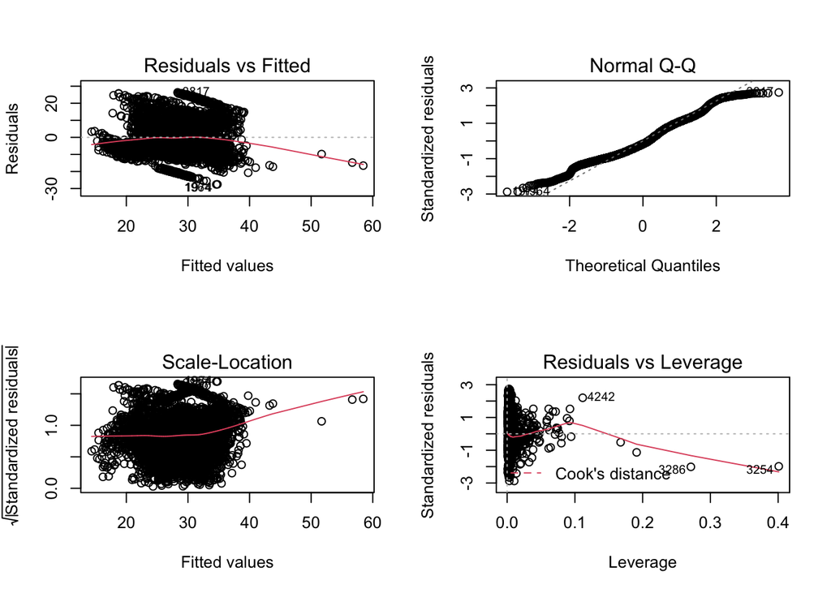

```r
parkinsons_predict <- predict(parkinsons_model,x_test)
par(mfrow=c(2,2))
plot(parkinsons_model)
```

#5 Build a Multiple linear regression with an interaction term

```r
parkinsons_model_interaction <- lm(total_UPDRS_train~ age+test_time+sex
                       +`Jitter(Abs)`+ `Jitter:RAP`*`Jitter:DDP`+`Jitter:PPQ5`
                       +Shimmer+`Shimmer(dB)`+`Shimmer:APQ3`*`Shimmer:DDA`
                       +`Shimmer:APQ5`+`Shimmer:APQ11`+ NHR+HNR
                       +RPDE+(`Jitter(%)`)+DFA+PPE, data = x_train)
summary(parkinsons_model_interaction)
```

```
##
## Call:
## lm(formula = total_UPDRS_train ~ age + test_time + sex + `Jitter(Abs)` +
##     `Jitter:RAP` * `Jitter:DDP` + `Jitter:PPQ5` + Shimmer + `Shimmer(dB)` +
##     `Shimmer:APQ3` * `Shimmer:DDA` + `Shimmer:APQ5` + `Shimmer:APQ11` +
##     NHR + HNR + RPDE + (`Jitter(%)`) + DFA + PPE, data = x_train)
##
## Residuals:
##     Min      1Q  Median      3Q     Max
## -29.826  -7.310  -1.700   7.282  26.824
##
## Coefficients:
##                                Estimate Std. Error t value Pr(>|t|)
## (Intercept)                   4.006e+01  3.638e+00  11.014  < 2e-16 ***
## age                           3.084e-01  1.679e-02  18.372  < 2e-16 ***
## test_time                     1.615e-02  2.654e-03   6.085 1.26e-09 ***
## sex                          -3.483e+00  3.687e-01  -9.449  < 2e-16 ***
## `Jitter(Abs)`                -1.033e+05  1.294e+04  -7.983 1.79e-15 ***
## `Jitter:RAP`                 -4.873e+04  5.157e+04  -0.945  0.34475
## `Jitter:DDP`                  1.680e+04  1.719e+04   0.977  0.32840
## `Jitter:PPQ5`                -4.871e+02  2.163e+02  -2.252  0.02435 *
## Shimmer                       2.319e+02  7.425e+01   3.123  0.00180 **
## `Shimmer(dB)`                -8.380e+00  5.650e+00  -1.483  0.13811
## `Shimmer:APQ3`                7.222e+03  5.193e+04   0.139  0.88939
## `Shimmer:DDA`                -2.558e+03  1.731e+04  -0.148  0.88254
## `Shimmer:APQ5`               -6.443e+01  6.098e+01  -1.057  0.29073
## `Shimmer:APQ11`               4.120e+01  2.737e+01   1.505  0.13233
## NHR                          -2.779e+01  7.051e+00  -3.941 8.22e-05 ***
## HNR                          -6.515e-01  8.004e-02  -8.140 5.03e-16 ***
## RPDE                          6.075e+00  2.025e+00   2.999  0.00272 **
## `Jitter(%)`                   2.132e+02  2.405e+02   0.886  0.37541
## DFA                          -3.210e+01  2.559e+00 -12.544  < 2e-16 ***
## PPE                           1.564e+01  3.378e+00   4.630 3.75e-06 ***
## `Jitter:RAP`:`Jitter:DDP`    -5.667e+03  1.339e+03  -4.231 2.37e-05 ***
## `Shimmer:APQ3`:`Shimmer:DDA`  4.056e+02  1.228e+02   3.304  0.00096 ***
## ---
## Signif. codes:  0 '***' 0.001 '**' 0.01 '*' 0.05 '.' 0.1 ' ' 1
##
## Residual standard error: 9.603 on 4678 degrees of freedom
## Multiple R-squared:  0.1853, Adjusted R-squared:  0.1817
## F-statistic: 50.68 on 21 and 4678 DF,  p-value: < 2.2e-16
```

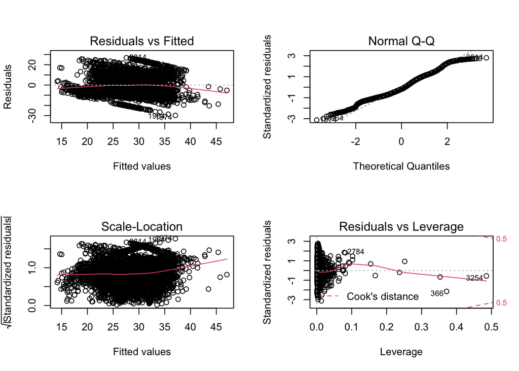

```r
interaction_prediction <- predict(parkinsons_model_interaction,x_test,
                                  interval = 'prediction')
#interaction_prediction
par(mfrow=c(2,2))
plot(parkinsons_model_interaction)
```

5.a formula = total_UPDRS_train ~ age + test_time + sex + `Jitter(Abs)` + `Jitter:RAP` * `Jitter:DDP` + `Jitter:PPQ5` + Shimmer + `Shimmer(dB)` + `Shimmer:APQ3` * `Shimmer:DDA` + `Shimmer:APQ5` + `Shimmer:APQ11` + NHR + HNR + RPDE + (`Jitter(%)`) + DFA + PPE

5.b. The Interaction terms here that were chosen were specifically chosen based on the obvious correlation that could be seen between the different variables such as that linear relationship between `Shimmer:APQ3`*`Shimmer:DDA`.

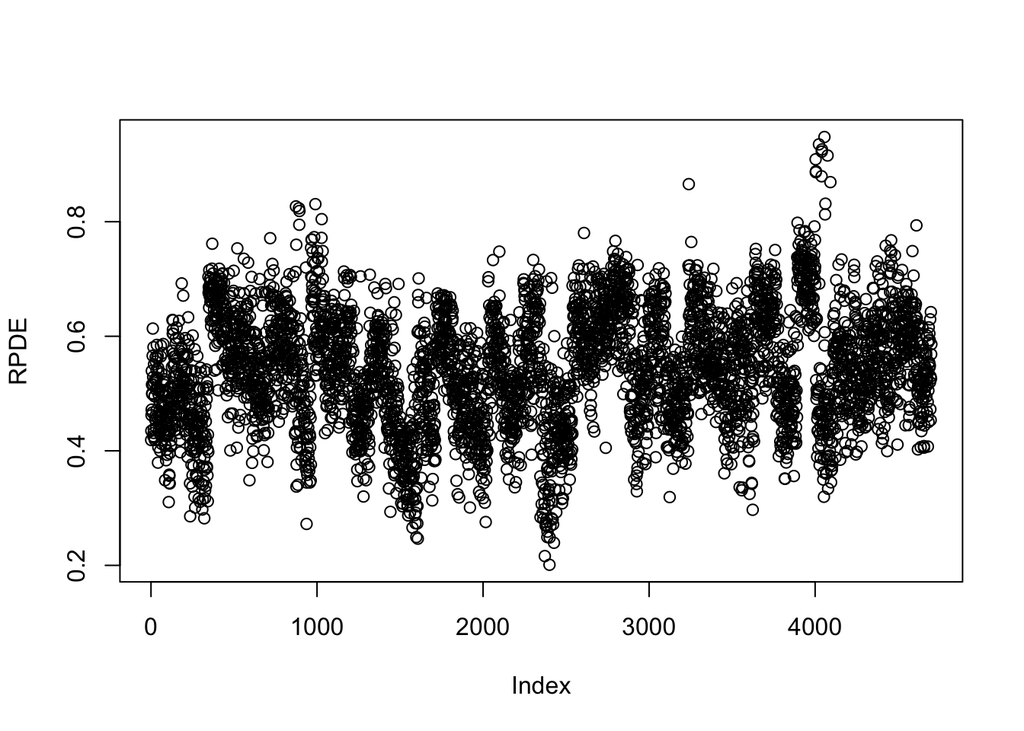

```r
plot(RPDE)
```

#6 model with nonlinearity

```r
parkinsons_model_nonlinearity <- lm(total_UPDRS_train~ age+test_time+sex
                       +`Jitter(Abs)`+ `Jitter:RAP`+`Jitter:DDP`+`Jitter:PPQ5`
                       +Shimmer+`Shimmer(dB)`+`Shimmer:APQ3`+`Shimmer:DDA`
                       +`Shimmer:APQ5`+`Shimmer:APQ11`+ NHR+HNR
                       +sin(RPDE)+`Jitter(%)`+DFA+PPE, data = x_train)
summary(parkinsons_model_nonlinearity)
```

```
##
## Call:
## lm(formula = total_UPDRS_train ~ age + test_time + sex + `Jitter(Abs)` +
##     `Jitter:RAP` + `Jitter:DDP` + `Jitter:PPQ5` + Shimmer + `Shimmer(dB)` +
##     `Shimmer:APQ3` + `Shimmer:DDA` + `Shimmer:APQ5` + `Shimmer:APQ11` +
##     NHR + HNR + sin(RPDE) + `Jitter(%)` + DFA + PPE, data = x_train)
##
## Residuals:
##     Min      1Q  Median      3Q     Max
## -27.605  -7.312  -1.655   7.362  26.456
##
## Coefficients:
##                   Estimate Std. Error t value Pr(>|t|)
## (Intercept)      3.715e+01  3.599e+00  10.322  < 2e-16 ***
## age              3.078e-01  1.675e-02  18.375  < 2e-16 ***
## test_time        1.563e-02  2.659e-03   5.879 4.41e-09 ***
## sex             -2.950e+00  3.515e-01  -8.393  < 2e-16 ***
## `Jitter(Abs)`   -7.715e+04  1.145e+04  -6.739 1.79e-11 ***
## `Jitter:RAP`    -4.964e+04  5.170e+04  -0.960  0.33704
## `Jitter:DDP`     1.684e+04  1.723e+04   0.977  0.32870
## `Jitter:PPQ5`   -5.568e+02  2.139e+02  -2.603  0.00926 **
## Shimmer          2.022e+02  7.383e+01   2.738  0.00621 **
## `Shimmer(dB)`   -8.923e+00  5.531e+00  -1.613  0.10676
## `Shimmer:APQ3`   5.781e+03  5.206e+04   0.111  0.91159
## `Shimmer:DDA`   -2.019e+03  1.735e+04  -0.116  0.90738
## `Shimmer:APQ5`  -4.730e+01  6.084e+01  -0.777  0.43697
## `Shimmer:APQ11`  1.968e+01  2.687e+01   0.732  0.46412
## NHR             -1.833e+01  6.760e+00  -2.712  0.00672 **
## HNR             -5.797e-01  7.591e-02  -7.637 2.69e-14 ***
## sin(RPDE)        6.464e+00  2.349e+00   2.752  0.00595 **
## `Jitter(%)`      2.457e+02  2.397e+02   1.025  0.30549
## DFA             -3.155e+01  2.563e+00 -12.309  < 2e-16 ***
## PPE              1.830e+01  3.266e+00   5.601 2.25e-08 ***
## ---
## Signif. codes:  0 '***' 0.001 '**' 0.01 '*' 0.05 '.' 0.1 ' ' 1
##
## Residual standard error: 9.629 on 4680 degrees of freedom
## Multiple R-squared:  0.1807, Adjusted R-squared:  0.1773
## F-statistic: 54.32 on 19 and 4680 DF,  p-value: < 2.2e-16
```

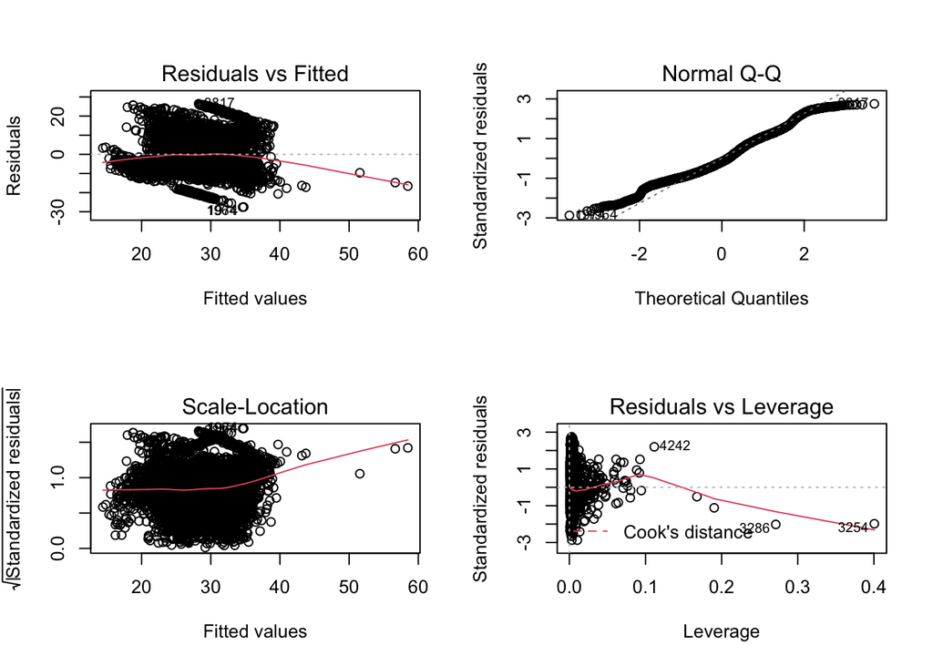

```r
nonlinearity_prediction <- predict(parkinsons_model_nonlinearity,x_test,
                                  interval = 'prediction')
par(mfrow=c(2,2))
plot(parkinsons_model_nonlinearity)
```

6.a. formula = total_UPDRS_train ~ age + test_time + sex + `Jitter(Abs)` + `Jitter:RAP` + `Jitter:DDP` + `Jitter:PPQ5` + Shimmer + `Shimmer(dB)` + `Shimmer:APQ3` + `Shimmer:DDA` + `Shimmer:APQ5` + `Shimmer:APQ11` + NHR + HNR + sin(RPDE) + `Jitter(%)` + DFA + PPE

6.b. In this case of non linearity I tried many different functions with the attempt to improve the model. After plotting RPDE I saw a louse shape of a sin curve so I attempted that in my final model,but other iterations of this model included ^3 a few interaction terms, cubing HNR and NHR, and other combinations, but as I continued different attempts none of them ever made a difference in improving the model therefore this model has the same rsquared and RSE values.

#7 Show Diagnostic plots of all three models above. As you can see by the rsquared values mentioned above there is not much movement in the performance. This being said: The main plot to look at in the shown diagnostic plots are the residuals vs fitted plots. In this plot, a perfect model will have a completely straight trend line. You can clearly see the trend line straightening from the fitted vs residuals plot in the first model to that in the interactions model

This supports the evidence provided by the rsquared values.